# Survival analysis

# 1 Data set description

Data set depicts survival in a randomised trial comparing two treatments for ovarian cancer.

Following variables are present:

**futime**: survival or censoring time

**fustat**: censoring status

**age**: in years

**resid.ds**: residual disease present (1=no,2=yes)

**rx**: treatment group

**ecog.ps**: [ECOG performance status](https://ecog-acrin.org/resources/ecog-performance-status)

# 2 Exploratory data analysis

Data has following structure:

```
'data.frame':   26 obs. of  6 variables:
 $ futime  : num  59 115 156 421 431 448 464 475 477 563 ...
 $ fustat  : num  1 1 1 0 1 0 1 1 0 1 ...
 $ age     : num  72.3 74.5 66.5 53.4 50.3 ...
 $ resid.ds: num  2 2 2 2 2 1 2 2 2 1 ...
 $ rx      : num  1 1 1 2 1 1 2 2 1 2 ...
 $ ecog.ps : num  1 1 2 1 1 2 2 2 1 2 ...
```

Variables **fustat**, **resid.ds**, **rx** and **ecog.ps** can be converted to factors.

Data has only **26** observations.

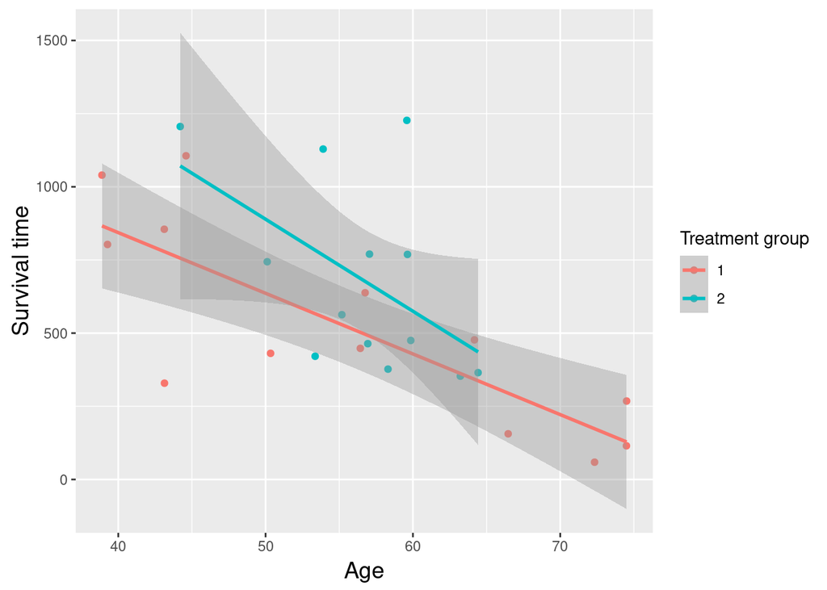

Variables **age** and **futime** are negatively correlated (**r = -0.6483612, p-value = 0.000341**)

Groups formed by categorical variables are badly balanced, probably due to lack of observations.

| fustat | resid.ds | rx | ecog.ps | n |
| --- | --- | --- | --- | --- |
| 0 | 1 | 1 | 1 | 2 |
| 0 | 1 | 1 | 2 | 2 |
| 0 | 1 | 2 | 1 | 3 |
| 0 | 1 | 2 | 2 | 1 |
| 0 | 2 | 1 | 1 | 1 |
| 0 | 2 | 1 | 2 | 1 |
| 0 | 2 | 2 | 1 | 3 |
| 0 | 2 | 2 | 2 | 1 |
| 1 | 1 | 1 | 2 | 1 |
| 1 | 1 | 2 | 2 | 2 |

[output cut: 4 more lines]

# 3 Survival analysis

## 3.1 Kaplan–Meier curves

First, we need to build model using **fustat** and **futime** variables. This will describe changes in survival chances depending on time.

```
Call: survfit(formula = Surv(futime, fustat) ~ 1, data = ova)

 time n.risk n.event survival std.err lower 95% CI upper 95% CI
    1     26       0    1.000  0.0000        1.000        1.000
   30     26       0    1.000  0.0000        1.000        1.000
   60     25       1    0.962  0.0377        0.890        1.000
   90     25       0    0.962  0.0377        0.890        1.000
  180     23       2    0.885  0.0627        0.770        1.000
  270     22       1    0.846  0.0708        0.718        0.997
  360     20       2    0.769  0.0826        0.623        0.949
  450     15       2    0.688  0.0919        0.529        0.894
  540     12       2    0.596  0.0999        0.429        0.828
  630     11       1    0.546  0.1032        0.377        0.791
  720     10       1    0.497  0.1051        0.328        0.752
  810      6       0    0.497  0.1051        0.328        0.752
  900      5       0    0.497  0.1051        0.328        0.752
```

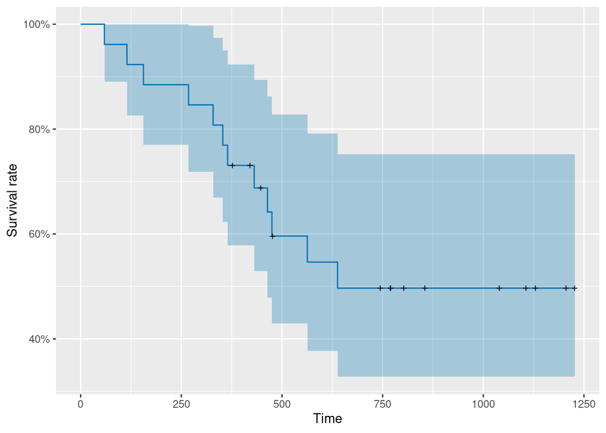

We can see very large CIs. Again, this may be caused by insufficiency of observations. However this model yields a little information, we can analyze survival rate depending on other factors.

### 3.1.1 Survival rate depending on ECOG status

```
Call: survfit(formula = Surv(futime, fustat) ~ ecog.ps, data = ova)

                ecog.ps=1
 time n.risk n.event survival std.err lower 95% CI upper 95% CI
    1     14       0    1.000  0.0000        1.000        1.000
   30     14       0    1.000  0.0000        1.000        1.000
   60     13       1    0.929  0.0688        0.803        1.000
   90     13       0    0.929  0.0688        0.803        1.000
  180     12       1    0.857  0.0935        0.692        1.000
  270     12       0    0.857  0.0935        0.692        1.000
  360     11       1    0.786  0.1097        0.598        1.000
  450      7       2    0.625  0.1347        0.410        0.953
  540      6       0    0.625  0.1347        0.410        0.953
  630      6       0    0.625  0.1347        0.410        0.953
  720      6       0    0.625  0.1347        0.410        0.953
```

[output cut: 18 more lines]

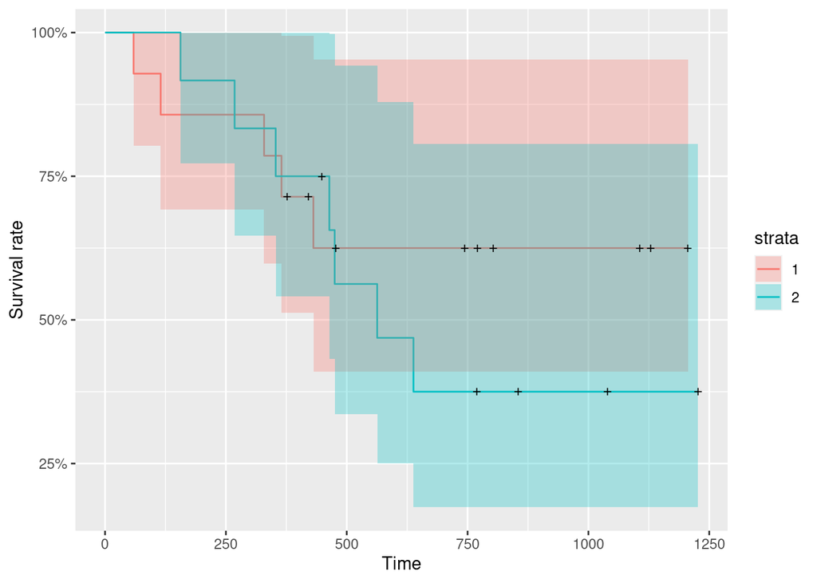

```
    Asymptotic Two-Sample Logrank Test

data:  Surv(futime, fustat) by ecog.ps (1, 2)
Z = 0.69106, p-value = 0.4895
alternative hypothesis: true theta is not equal to 1
```

```
    Pairwise comparisons using Log-Rank test

data:  ova and ecog.ps

  1
2 0.49

P value adjustment method: BH
```

Survival rate does not significantly differ between ECOG status 1 and 2.

### 3.1.2 Survival rate depending on treatment

```
Call: survfit(formula = Surv(futime, fustat) ~ rx, data = ova)

                rx=1
 time n.risk n.event survival std.err lower 95% CI upper 95% CI
    1     13       0    1.000  0.0000        1.000        1.000
   30     13       0    1.000  0.0000        1.000        1.000
   60     12       1    0.923  0.0739        0.789        1.000
   90     12       0    0.923  0.0739        0.789        1.000
  180     10       2    0.769  0.1169        0.571        1.000
  270      9       1    0.692  0.1280        0.482        0.995
  360      8       1    0.615  0.1349        0.400        0.946
  450      6       1    0.538  0.1383        0.326        0.891
  540      5       0    0.538  0.1383        0.326        0.891
  630      5       0    0.538  0.1383        0.326        0.891
  720      4       1    0.431  0.1467        0.221        0.840
```

[output cut: 18 more lines]

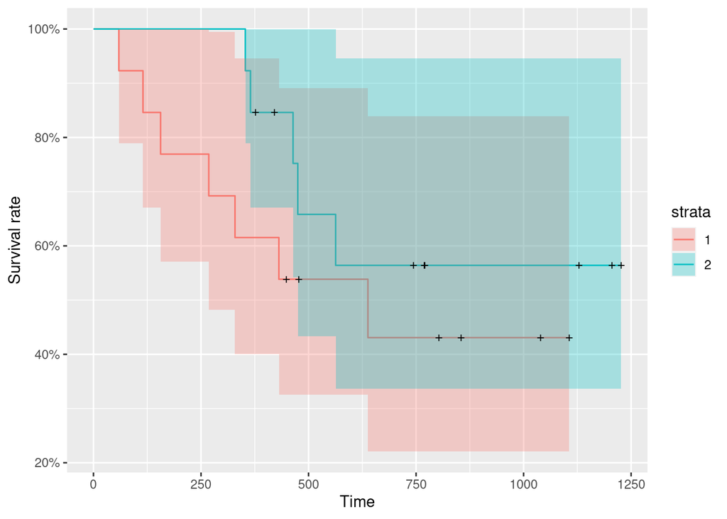

```
    Asymptotic Two-Sample Logrank Test

data:  Surv(futime, fustat) by rx (1, 2)
Z = -1.0296, p-value = 0.3032
alternative hypothesis: true theta is not equal to 1
```

Survival rate does not significantly differ between different treatment types.

### 3.1.3 Survival rate depending on residual disease presence

```
Call: survfit(formula = Surv(futime, fustat) ~ resid.ds, data = ova)

                resid.ds=1
 time n.risk n.event survival std.err lower 95% CI upper 95% CI
    1     11       0    1.000  0.0000        1.000            1
   30     11       0    1.000  0.0000        1.000            1
   60     11       0    1.000  0.0000        1.000            1
   90     11       0    1.000  0.0000        1.000            1
  180     11       0    1.000  0.0000        1.000            1
  270     11       0    1.000  0.0000        1.000            1
  360     10       1    0.909  0.0867        0.754            1
  450      8       0    0.909  0.0867        0.754            1
  540      8       0    0.909  0.0867        0.754            1
  630      7       1    0.795  0.1306        0.577            1
  720      6       1    0.682  0.1536        0.438            1
```

[output cut: 18 more lines]

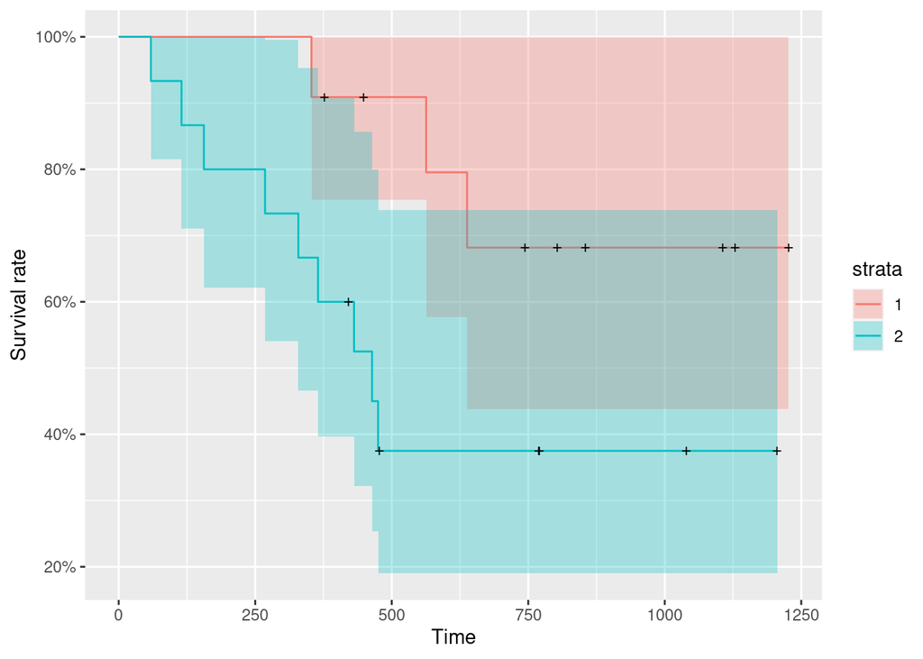

```
    Asymptotic Two-Sample Logrank Test

data:  Surv(futime, fustat) by resid.ds (1, 2)
Z = 1.9234, p-value = 0.05444
alternative hypothesis: true theta is not equal to 1
```

Survival rate does not significantly differ depending on residual disease presence.

### 3.1.4 Survival rate depending on age group

```
Call: survfit(formula = Surv(futime, fustat) ~ age_groups, data = ova)

                age_groups=Older than 57
 time n.risk n.event survival std.err lower 95% CI upper 95% CI
    1     12       0    1.000  0.0000        1.000        1.000
   30     12       0    1.000  0.0000        1.000        1.000
   60     11       1    0.917  0.0798        0.773        1.000
   90     11       0    0.917  0.0798        0.773        1.000
  180      9       2    0.750  0.1250        0.541        1.000
  270      8       1    0.667  0.1361        0.447        0.995
  360      7       1    0.583  0.1423        0.362        0.941
  450      5       1    0.500  0.1443        0.284        0.880
  540      3       1    0.400  0.1461        0.196        0.818
  630      3       0    0.400  0.1461        0.196        0.818
  720      3       0    0.400  0.1461        0.196        0.818
```

[output cut: 18 more lines]

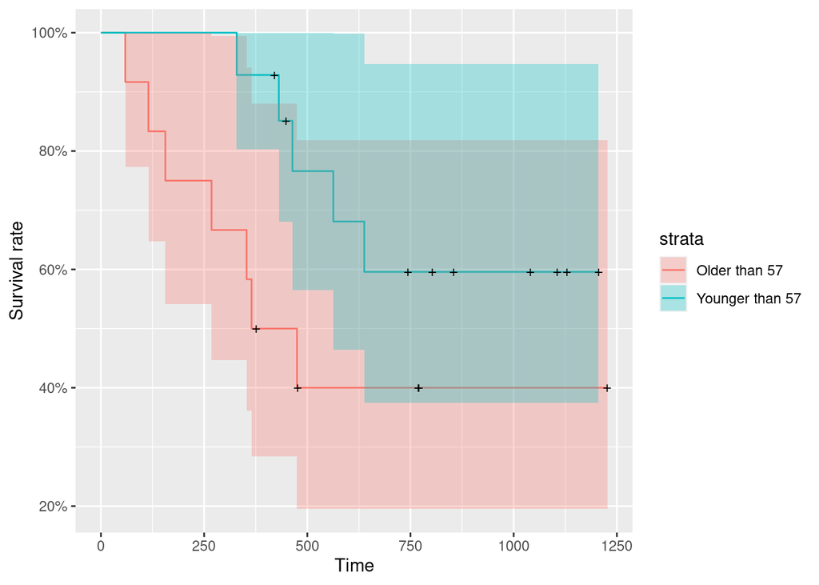

```
    Asymptotic Two-Sample Logrank Test

data:  Surv(futime, fustat) by
     age_groups (Older than 57, Younger than 57)
Z = -1.5717, p-value = 0.116
alternative hypothesis: true theta is not equal to 1
```

Survival rate does not significantly differ depending on age groups.

### 3.1.5 Survival rate depending on age group and treatment

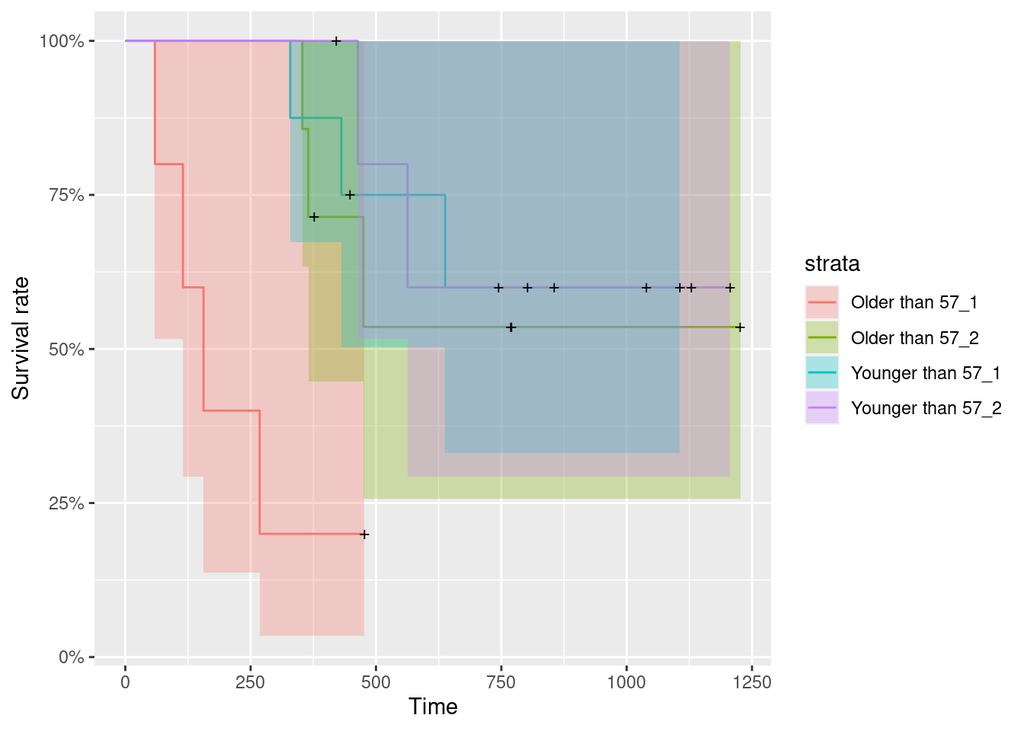

```
    Pairwise comparisons using Peto & Peto test

data:  ova and agerx

                  Older than 57_1 Older than 57_2 Younger than 57_1
Older than 57_2   0.130           -               -
Younger than 57_1 0.047           1.000           -
Younger than 57_2 0.099           1.000           1.000

P value adjustment method: bonferroni
```

Here **peto & peto logrank test** was made and bonferroni adjustment was applied, because now we have 4 groups to compare. We can notice that type 1 treated people in different age groups significantly differ in survival rates.

### 3.1.6 Survival rate depending on residual disease presence and treatment

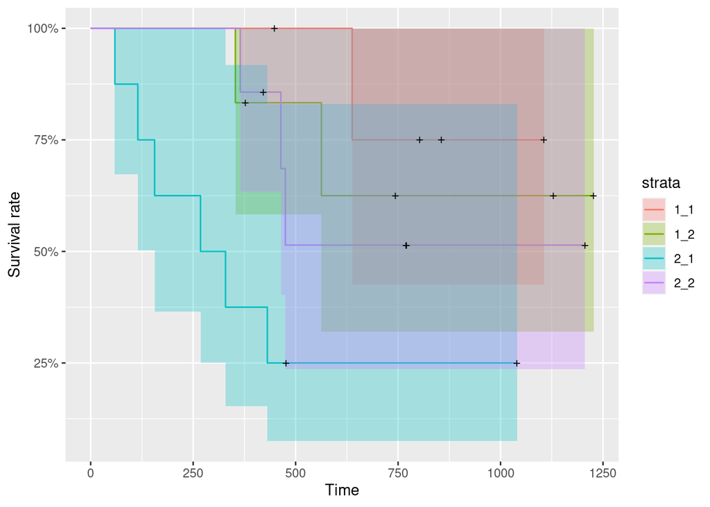

```
    Pairwise comparisons using Peto & Peto test

data:  ova and residrx

    1_1  1_2  2_1
1_2 1.00 -    -
2_1 0.18 0.25 -
2_2 1.00 1.00 0.27

P value adjustment method: bonferroni
```

According to logrank test with bonferroni adjustment these groups do not have any significant differences in survival rate.

## 3.2 Analysis of hazard factors

### 3.2.1 Proportional hazards regression model

To estimate hazard factors Cox model can be built.

```
Call:
coxph(formula = Surv(futime, fustat) ~ resid.ds + ecog.ps + rx +
    age_groups, data = ova)

  n= 26, number of events= 12

                             coef exp(coef) se(coef)      z Pr(>|z|)
resid.ds2                  1.0085    2.7414   0.7357  1.371   0.1705
ecog.ps2                   0.4757    1.6091   0.5982  0.795   0.4265
rx2                       -1.1006    0.3327   0.6581 -1.672   0.0944 .
age_groupsYounger than 57 -0.9973    0.3689   0.7089 -1.407   0.1595
---
Signif. codes:  0 '***' 0.001 '**' 0.01 '*' 0.05 '.' 0.1 ' ' 1

                          exp(coef) exp(-coef) lower .95 upper .95
resid.ds2                    2.7414     0.3648   0.64824    11.593
ecog.ps2                     1.6091     0.6215   0.49821     5.197
rx2                          0.3327     3.0060   0.09159     1.208
age_groupsYounger than 57    0.3689     2.7110   0.09194     1.480

Concordance= 0.755  (se = 0.067 )
Likelihood ratio test= 8.15  on 4 df,   p=0.09
Wald test            = 7.22  on 4 df,   p=0.1
Score (logrank) test = 7.92  on 4 df,   p=0.09
```

This model does not yield any covariates. This could happen because **age** variable directly depends on time and Cox model assumes that it is not. So we can remove this variable from our model.

```
Call:
coxph(formula = Surv(futime, fustat) ~ resid.ds + ecog.ps + rx,
    data = ova)

  n= 26, number of events= 12

             coef exp(coef) se(coef)      z Pr(>|z|)
resid.ds2  1.3466    3.8444   0.6803  1.980   0.0478 *
ecog.ps2   0.4528    1.5727   0.5903  0.767   0.4431
rx2       -0.7493    0.4727   0.5949 -1.260   0.2078
---
Signif. codes:  0 '***' 0.001 '**' 0.01 '*' 0.05 '.' 0.1 ' ' 1

          exp(coef) exp(-coef) lower .95 upper .95
resid.ds2    3.8444     0.2601    1.0134    14.584
ecog.ps2     1.5727     0.6359    0.4945     5.002
rx2          0.4727     2.1156    0.1473     1.517

Concordance= 0.741  (se = 0.074 )
Likelihood ratio test= 6.03  on 3 df,   p=0.1
Wald test            = 5.44  on 3 df,   p=0.1
Score (logrank) test = 5.83  on 3 df,   p=0.1
```

Now we can see that residual disease presence became significant hazard factor. However we need to check if it is not changing in time.

To do that we can build Aalen model and visualize it:

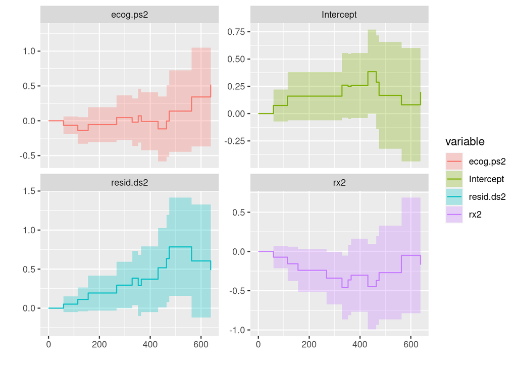

On this chart we can see that **resid.ds2** changes over time and thus should be interpreted with caution.

### 3.2.2 Hazard ratio

In order to characterize differences in survival rates numerically we can use hazard ratios (HRs).

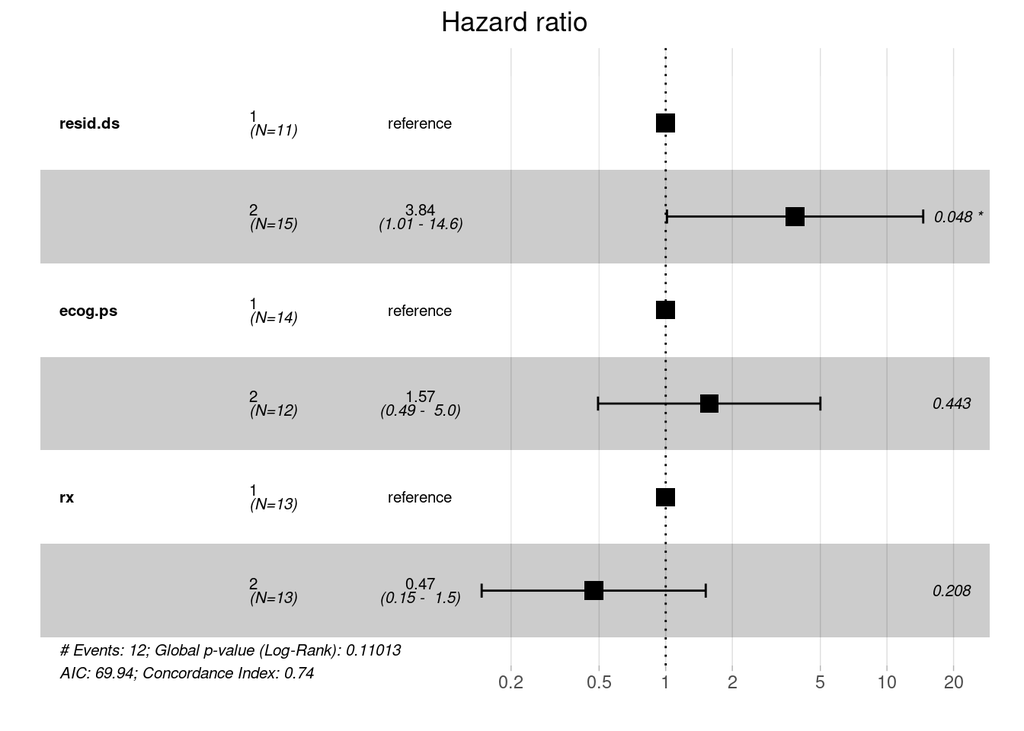

```r
fit.coxph <- coxph(Surv(futime, fustat) ~ resid.ds + ecog.ps + rx, data = ova)
ggforest(fit.coxph, data = ova)
```

# 4 Conclusion

Here we made a survival analysis of ovarian data set.